# R Notebook

1.Plot the unadjusted series, its ACF & PACF, and comment on the following characteristics: trend, seasonality, stationarity

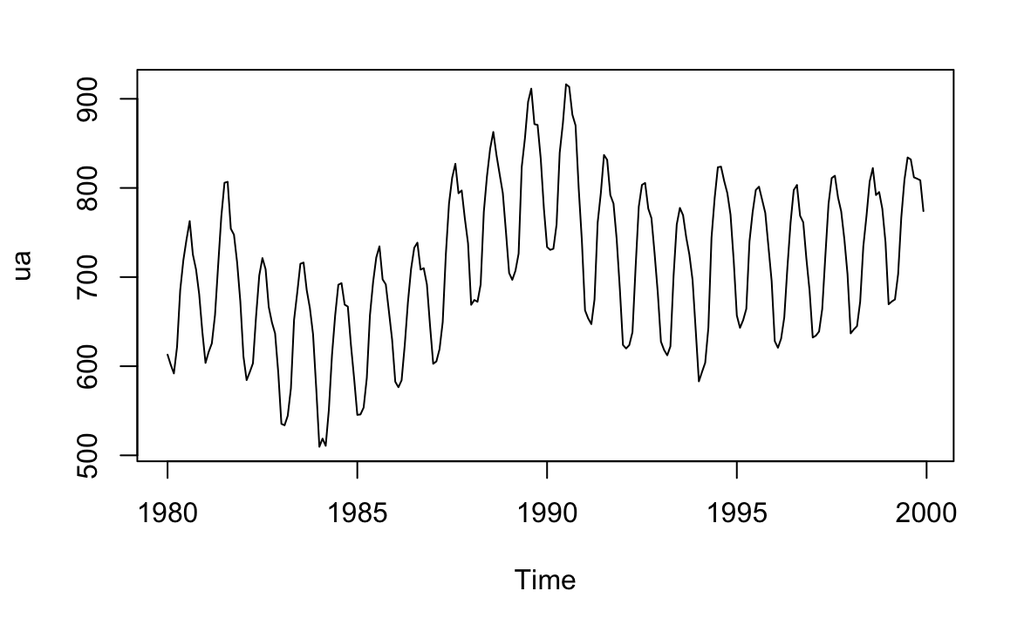

```r
library(cansim)
library(tidyverse)
ua = get_cansim_vector( "v2057817", start_time = "1980-01-01", end_time = "1999-12-01") %>% pull(VALUE) %>% ts( start = c(1980,1), frequency = 12)
plot(ua)
```

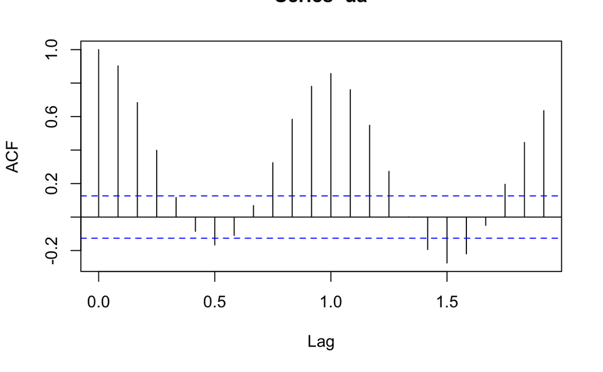

```r
acf(ua)
```

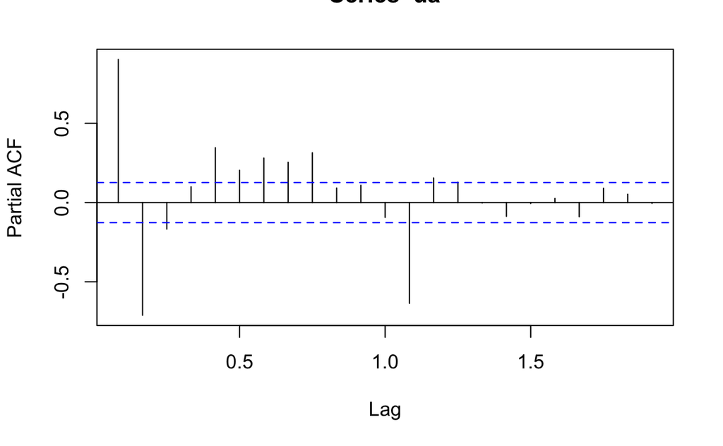

```r
pacf(ua)
```

2. [5 marks] Perform a classical multiplicative decomposition of the unadjusted series (Xua) into trend (T), seasonal (S), and remainder (R) components (i.e. Xua = T × S × R):

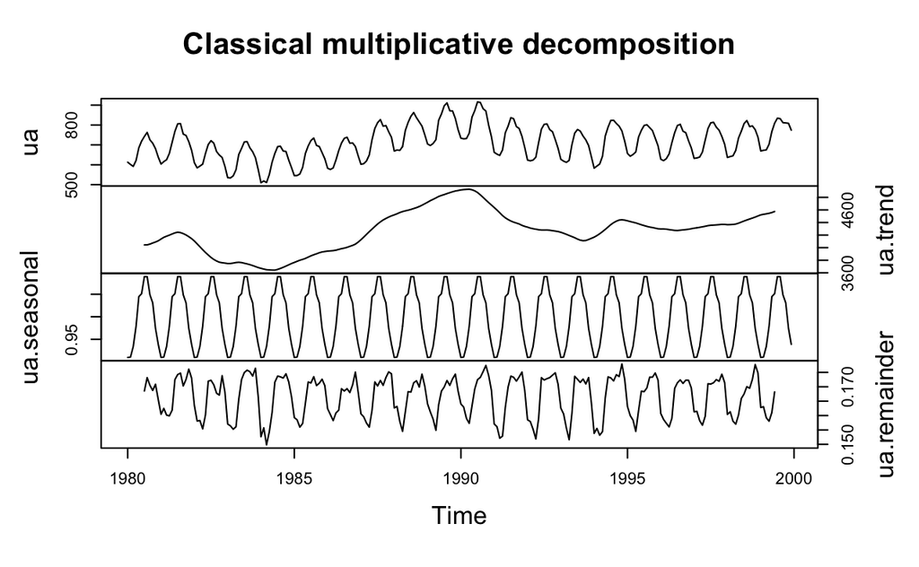

```r
ua.trend=stats::filter(ua,c(.5,rep(1,11),.5)/2,method="convo",sides=2)
trend = ua/ua.trend
ll <- length(trend)
ff <- frequency(trend)
periods <- ll %/%ff
index <- seq(1,ll,by=ff)-1
mm <- numeric(ff)
for ( i in 1:ff) {
  mm[i] <- mean(trend[index+i],na.rm=TRUE)
}
seaonal <- mm/mean((mm))
ua.seasonal <- ts(rep(seasonal,periods+1)[seq(ll)],start=1980,frequency=ff)
ua.remainder <- ua/(ua.trend*ua.seasonal)
plot(cbind(ua,ua.trend,ua.seasonal,ua.remainder),main="Classical multiplicative decomposition",yax.flip = TRUE)
```

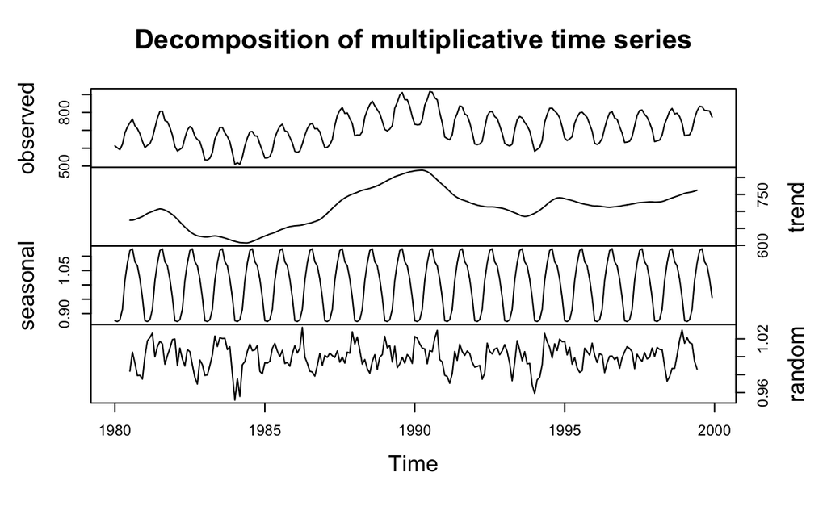

```r
a<-decompose(ua,type="multiplicative")
plot(a,yax.flip=TRUE)
```

3.Statistics Canada (StatCan) does their own seasonal adjustment using a more sophisticated method (namely, X-12-ARIMA). Download the corresponding seasonally adjusted series for your industry and time period, and plot them on the same plot with your own seasonally adjusted data (Xsa = Xua/S = T × R) from the previous part. The two versions should be close, but not identical. Report the mean absolute error (MAE) between the two versions (StaCan’s and yours) of seasonally adjusted data.

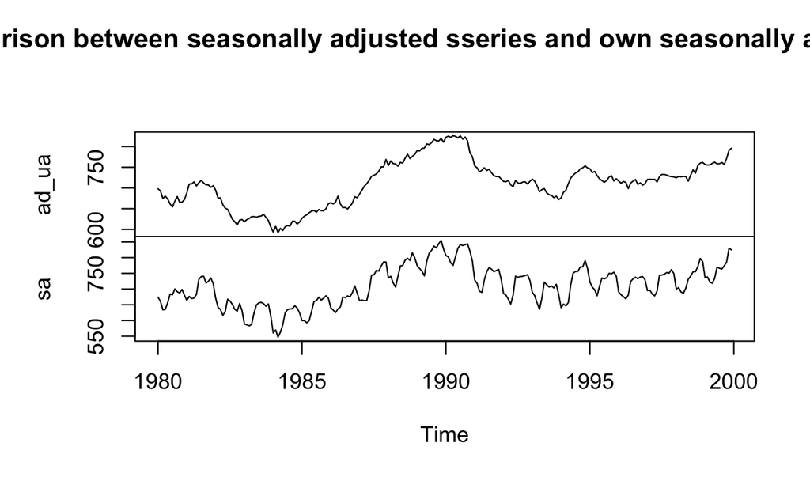

```r
ad_ua <- get_cansim_vector( "v2057608", start_time = "1980-01-01", end_time = "1999-12-01") %>% pull(VALUE) %>% ts( start = c(1980,1), frequency = 12)
sa=ua/seasonal
plot(cbind(ad_ua,sa),main="comparison between seasonally adjusted sseries and own seasonally adjusted data")
```

```r
mae <- mean(abs(sa-ad_ua))
mae
```

```
[1] 25.98923
```

```r
MAE.x11
```

[output not shown]

[output not shown]

```r
ua.seats <- seas(ua)
adj.seats<-seasadj(ua.seats)
sea.seats<-seasonal(ua.seats)
tre.seats<-trendcycle(ua.seats)
rem.seats<-remainder(ua.seats)
```

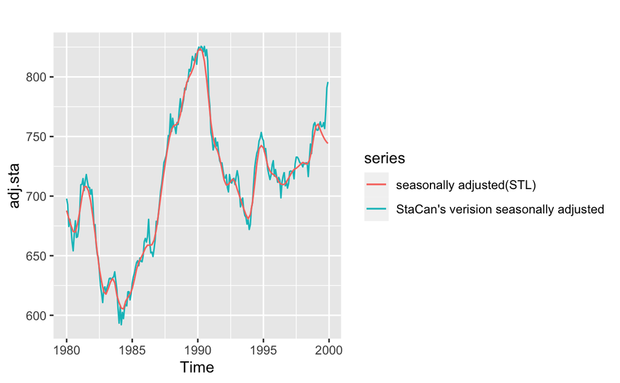

```r
logua<-log(ua)
logua.stl<-stl(logua,t.window=13,s.window="periodic",robust=TRUE)
logua.stl$time.series<-exp(logua.stl$time.series)
ua.stl<-logua.stl
adj.stl<-seasadj(ua.stl)
sea.stl<-seasonal(ua.stl)
tre.stl<-trendcycle(ua.stl)
rem.stl<-remainder(ua.stl)
autoplot(adj.sta,series = "StaCan's verision seasonally adjusted") +
 autolayer(adj.stl, series = "seasonally adjusted(STL)")
```

```r
MAE.stl <- mean(abs(adj.stl-adj.sta))
MAE.stl
```

```
[1] 5.959617
```

4.Using StatCan’s data (unadjusted, and/or seasonally adjusted, and/or trend-cycle), calculate the remainder series (R). Plot R and its sample ACF and PACF, and answer the following questions:

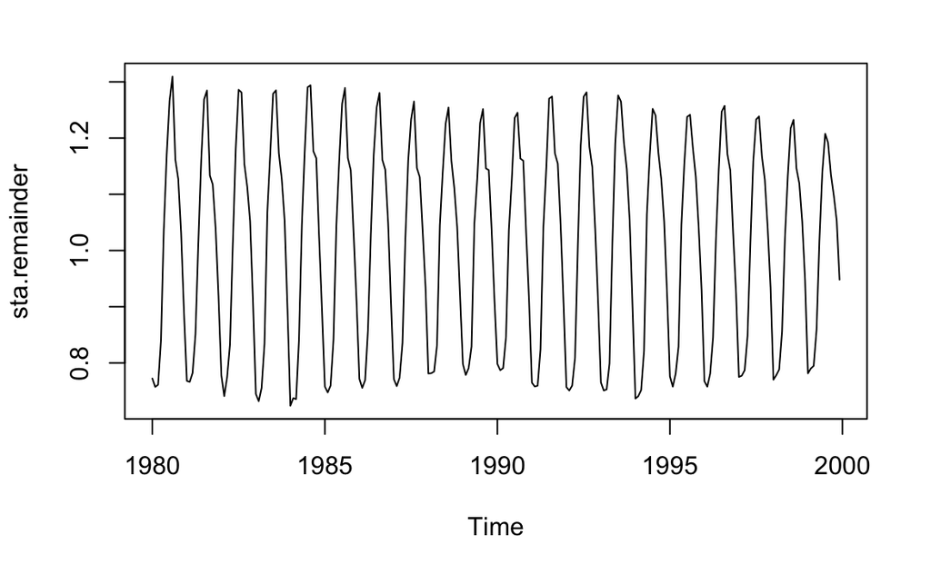

```r
sta.trend<-get_cansim_vector( "v123355111", start_time = "1980-01-01", end_time = "1999-12-01") %>% pull(VALUE) %>% ts( start = c(1980,1), frequency = 12)
sta.seasonal<-adj.sta/ua
sta.remainder <-ua/(sta.seasonal*sta.trend)
plot(sta.remainder)
```

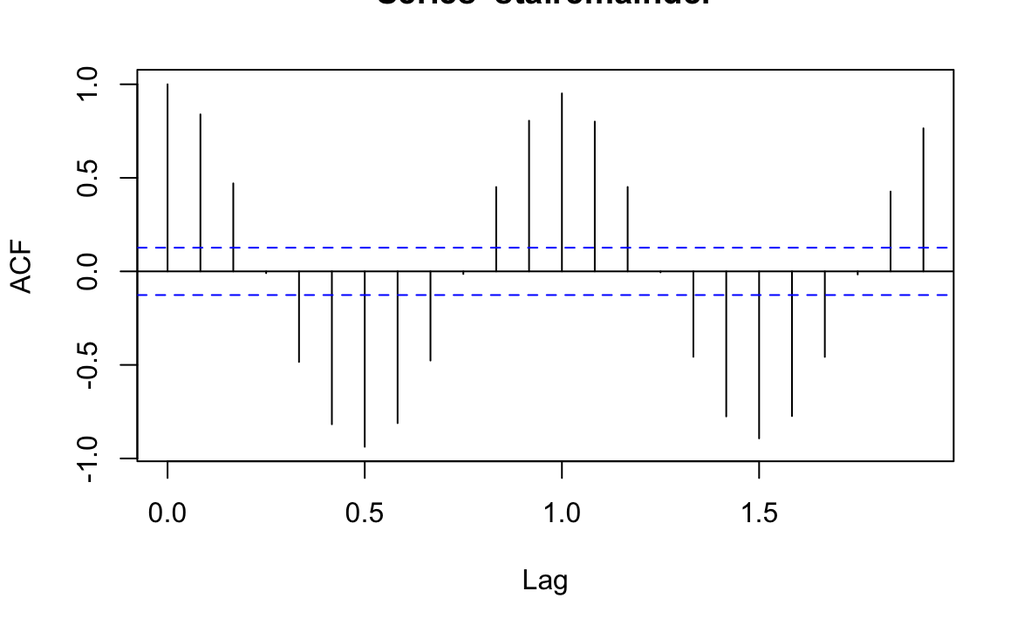

```r
acf(sta.remainder)
```

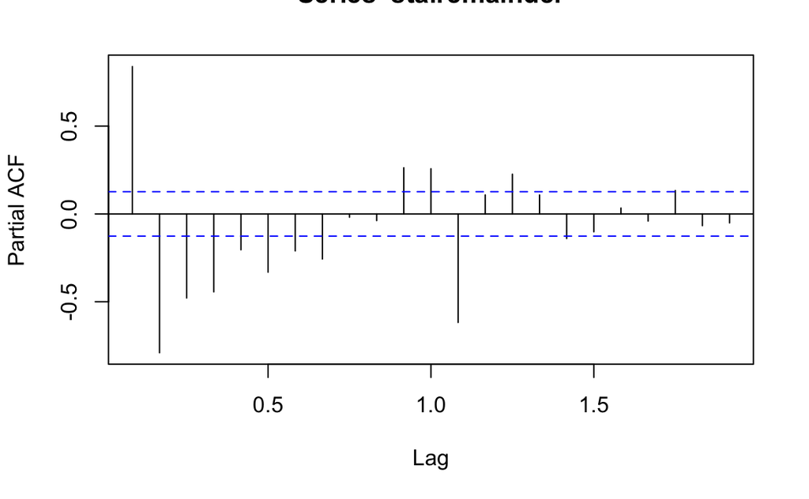

```r
pacf(sta.remainder)
```

1. Based on these plots, can you identify any remaining seasonality in your series?

2. Comment on the stationarity of the series and propose any further pre-processing.

It is hard to say that it acf shows that the stationarity. Since ACF does not drop to zero for larger lags, and there is no change in the pattern. We can differencing it, or work with subset of series.